# CEF Socio-economic indicators

This is a draft dashboard showing the key CEF socio-economic indicators used in the mock-up current condition report.

In this section we can link to our website or the pdf of the report:

[CEF Economic Report](https://www2.gov.bc.ca/gov/content/environment/natural-resource-stewardship/cumulative-effects-framework)

The Local Area Economic Profile Report is a new edition of an economic model that was previous called the Local Area Economic Dependencies and was last published by BC Stats in 2009. Results shown here are preliminary and BC Stats is seeking feedback from users. To provide feedback please email BCStats@gov.bc.ca. This project creates a consistent economic model for 103 local areas in British Columbia. It combines detailed census data with the province’s macroeconomic input-output model and is primarily intended to provide information on rural areas and to help estimate the impact of economic changes.

# Welcome Page

### Some demo text to explain the app and its context. This is super draft.

## Executive Summary

The distribution of economic activity plays a critical role in shaping the prosperity of regions, particularly in rural and resource-dependent communities. Economic resilience is influenced by the diversity of sectors, the stability of industries, and the broader economic landscape. When economies become overly reliant on a single sector, external shocks—such as shifts in commodity prices, policy changes such as tariffs, or environmental constraints—can have outsized impacts on local livelihoods.

Sector diversification, sustainable resource management, and strategic economic planning help buffer communities against these risks, supporting stable employment, attracting investment, and fostering long-term economic stability. Though a community with a dominant industry may be better off than one with a number of smaller industries, a diversified economic base will provide more community stability in uncertain economic times.

Additionally, the prosperity of a local community depends on much more than the economic performance of its basic industries. Culture, education level, income equality, investment levels, and environmental prosperity all contribute to local prosperity. Looking at select socio-economic indicators only provides an insight into some contributing factors of what drives and sustains local communities.

Economies are inherently complex, shaped by local, national, and global factors that cannot always be fully captured through quantitative data alone. While indicators such as employment rates, income levels, and industry outputs provide useful insights, they do not always dictate the best course of action for economic development. Context is essential—understanding the broader economic landscape allows decision-makers to assess challenges, identify emerging opportunities, and make informed choices tailored to the region’s specific circumstances.

This report compiles key economic data for the economic census region of BC, providing a structured synthesis of economic trends and conditions. It is not intended as a prescriptive economic development plan, nor does it outline specific policy recommendations. Instead, it serves as a foundational resource to help illuminate critical questions, risks, and opportunities facing communities in the region, equipping decision-makers with the necessary information to guide discussions and future strategies.

## Introduction

The Province of British Columbia (the Province) has developed the Cumulative Effects Framework (CEF) to measure the impacts of natural resource activities on values that are important to the people of British Columbia (B.C.). The CEF provides a structured approach to evaluating how multiple factors influence regional conditions, aiming to support informed decision-making and minimize unintended consequences. A core component of this framework is the assessment of current conditions, which provides a baseline understanding of key values.

This report examines the socio-economic conditions, synthesizing key indicators to provide an overview of the region’s economic landscape. Data and analysis presented here help frame the broader context in which communities operate. By compiling and interpreting relevant economic information, this report contributes to a clearer understanding of the factors shaping the region’s economy. The indicators presented in this report include:

- Employment rates by sectors
- Revenue brought in by each sector
- Economic resilience indicator
- Changes to employment over time
- Upcoming major projects
- The footprint of selected basic industries across the landscape (Forestry, Oil and Gas, Mining, and Agriculture)

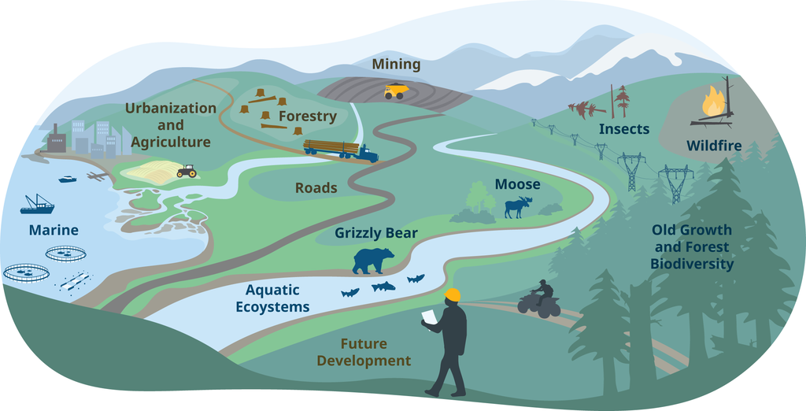